# Comparación umbrales pobreza: Nacional e Internacional

Juandiego Huete Petisco y Borja Pantín Alonso

2026-05-31

[figure not shown]

# Introducción

El objetivo de este trabajo es analizar los datos disponibles en el Banco Mundial sobre las tasas de pobreza a nivel mundial y examinar las diferencias, si las hubiera, entre la tasa de pobreza a nivel nacional y la tasa de pobreza a nivel internacional.

Para ello, en este trabajo hemos decidido utilizar estas dos variables: la tasa de pobreza a nivel nacional (SI.POV.NAHC) y la tasa de pobreza a nivel internacional (SI.POV.DDAY). Además, hemos utilizado los datos del PIB per cápita (NY.GDP.PCAP.CD) y la variable de población (SP.POP.TOTL). Además, analizaremos visualmente si existe relación entre los porcentajes de población que viven por debajo del umbral de pobreza, tanto nacional como internacional, en cada país, con las variables de la prevalencia de la desnutrición (SN.ITK.DEFC.ZS), la Tasa de finalización del ciclo inferior de la educación secundaria (SE.SEC.CMPT.LO.ZS), y la población que vive en barrios marginales (% de la población urbana) (EN.POP.SLUM.UR.ZS).

Nuestra hipótesis principal es que los países con el PIB más alto son aquellos con el menor porcentaje de población pobre.

```r
my_indicators <- c(
  umbral_pobreza_internacional = "SI.POV.DDAY",
  umbral_pobreza_nacional = "SI.POV.NAHC",
  desnutrición = "SN.ITK.DEFC.ZS",
  tasa_secundaria_inferior = "SE.SEC.CMPT.LO.ZS",
  poblacion_barrios_marginales = "EN.POP.SLUM.UR.ZS",
  PIB_capita ="NY.GDP.PCAP.CD",
  poblacion = "SP.POP.TOTL"
  )
```

## Manipulación de los datos

Para centrarnos mejor en nuestro tema principal, filtramos los datos de las dos variables relacionadas con la pobreza para conservar el último año con información disponible para ambas variables en la base de datos del Banco Mundial, eliminando así los datos faltantes de estas variables en nuestra investigación. A lo largo del trabajo, creamos tablas para comprender mejor los datos, ordenando los países según el mayor porcentaje de población por debajo del umbral de pobreza, tanto con las variables nacionales como internacionales, y con ambas simultáneamente; ordenándolos por áreas geográficas y observando cuál ofrece la mayor cantidad de datos para cada una, restando los datos obtenidos por la variable nacional de los obtenidos por la variable internacional, para así comprobar si existe una diferencia significativa. También creamos tablas donde aparece la variable PIB per cápita, para contrastar nuestra hipótesis.

Para que el trabajo fuera más visual y los datos más fáciles de entender, creamos un mapa que muestra los porcentajes de población pobre en cada país mediante una escala de color del amarillo al morado. Existen varios mapas: uno para la variable a nivel nacional, otro para el nivel internacional y un tercero para la diferencia entre ambas variables.

### Preparación de datos

Lo primero es preparar nuestros datos para poder operar con ellos.

```r
data_set <- wbstats::wb_data(my_indicators,)%>%
  left_join(wbstats::wb_countries() %>% select(-country), by="iso3c")
```

```r
data_set %>%
  group_by(country) %>%
  drop_na(umbral_pobreza_nacional) %>%
  drop_na(umbral_pobreza_internacional) %>%
  drop_na(desnutrición) %>%
  drop_na(tasa_secundaria_inferior) %>%
  drop_na(poblacion_barrios_marginales)
```

```
## # A tibble: 307 × 27
## # Groups:   country [90]
##    iso2c.x iso3c country    date poblacion_barrios_marginales PIB_capita
##    <chr>   <chr> <chr>     <dbl>                        <dbl>      <dbl>
##  1 AL      ALB   Albania    2008                         17.9      4499.
##  2 AL      ALB   Albania    2012                         12.9      4281.
##  3 AL      ALB   Albania    2018                          5.3      5898.
##  4 AL      ALB   Albania    2020                          2.8      6028.
##  5 AR      ARG   Argentina  2016                         14.5     12700.
##  6 AR      ARG   Argentina  2018                         14.5     11753.
##  7 AR      ARG   Argentina  2020                         14.5      8536.
##  8 AR      ARG   Argentina  2022                         14.5     13962.
##  9 AM      ARM   Armenia    2004                         11.8      1130.
## 10 AM      ARM   Armenia    2006                         11.3      2042.
## # ℹ 297 more rows
## # ℹ 21 more variables: tasa_secundaria_inferior <dbl>,
## #   umbral_pobreza_internacional <dbl>, umbral_pobreza_nacional <dbl>,
## #   desnutrición <dbl>, poblacion <dbl>, iso2c.y <chr>, capital_city <chr>,
## #   longitude <dbl>, latitude <dbl>, region_iso3c <chr>, region_iso2c <chr>,
## #   region <chr>, admin_region_iso3c <chr>, admin_region_iso2c <chr>,
## #   admin_region <chr>, income_level_iso3c <chr>, income_level_iso2c <chr>, …
```

## Visualización de los datos

Una vez hemos realizado este paso, hacemos una primera inmersión para conocer los datos, una especie de resumen como los que hemos hecho en clase con `head()` y `tail()`, pero más trabajada.

### Países con más porcentaje de población pobre, por región.

```r
pobnac = data_set %>%
     group_by(country) %>%
     drop_na(umbral_pobreza_nacional) %>%
     arrange(-date) %>%
     slice(1)
```

```r
pobint = data_set %>%
     group_by(country) %>%
     drop_na(umbral_pobreza_internacional) %>%
     arrange(-date) %>%
     slice(1)
```

```r
pobmix = data_set %>%
     group_by(country) %>%
     drop_na(umbral_pobreza_internacional) %>%
     drop_na(umbral_pobreza_nacional) %>%
     arrange(-date) %>%
     slice(1) %>%
     mutate(difference = umbral_pobreza_nacional - umbral_pobreza_internacional)
```

```r
pobna_reg = pobnac %>%
  left_join(codelist %>% rename(GeoAreaCode=iso3n)) %>%
  group_by(region) %>%
  slice_max(umbral_pobreza_nacional) %>%
  select(region,iso3c,country, umbral_pobreza_nacional, date) %>%
  arrange(-umbral_pobreza_nacional)
tab_pvnc_reg <- pobna_reg %>%
  ungroup()  %>%
  mutate(date=as.integer(date)) %>%
  flextable::flextable() %>%
  flextable::colformat_double(digits = 2) %>%
flextable::set_caption("Países con mayor porcentaje de población pobre (V. Nacional), por región")
```

```r
pobint_reg = pobint %>%
  left_join(codelist %>% rename(GeoAreaCode=iso3n)) %>%
  group_by(region) %>%
  slice_max(umbral_pobreza_internacional) %>%
  select(region,iso3c,country, umbral_pobreza_internacional, date) %>%
  arrange(-umbral_pobreza_internacional)
tab_pvint_reg <- pobint_reg %>%
  ungroup()  %>%
  mutate(date=as.integer(date)) %>%
  flextable::flextable() %>%
  flextable::colformat_double(digits = 2) %>%
flextable::set_caption("Países con mayor porcentaje de población pobre (V. Internacional), por región")
```

```r
pobmix_reg = pobmix %>%
  left_join(codelist %>% rename(GeoAreaCode=iso3n)) %>%
  group_by(region) %>%
  slice_max(difference) %>%
  select(region,iso3c,country, difference, date) %>%
  arrange(-difference)
tab_pvmix_reg <- pobmix_reg %>%
    ungroup()  %>%
  mutate(date=as.integer(date)) %>%
  flextable::flextable() %>%
  flextable::colformat_double(digits = 2) %>%
  flextable::set_caption("Países con mayor diferencia entre el indicador nacional e Internacional, por región")
```

El resultado de esto son estas 3 tablas, que nos muestran cuáles son los países por cada región con mayor porcentaje de población viviendo por debajo del umbral de pobreza, según los indicadores nacionales e internacionales; la última tabla nos muestra los países donde se observan mayores diferencias en el porcentaje de población pobre entre los indicadores nacionales e internacionales.

Países con mayor porcentaje de población pobre (V. Nacional), por región

| region | iso3c | country | Poverty headcount ratio at national poverty lines (% of population) | date |
| --- | --- | --- | --- | --- |
| Sub-Saharan Africa | SSD | South Sudan | 82.30 | 2,016 |
| Latin America & Caribbean | HND | Honduras | 60.10 | 2,025 |
| Middle East, North Africa, Afghanistan & Pakistan | YEM | Yemen, Rep. | 48.60 | 2,014 |
| East Asia & Pacific | TLS | Timor-Leste | 41.80 | 2,014 |
| Europe & Central Asia | MDA | Moldova | 31.60 | 2,023 |
| South Asia | IND | India | 21.90 | 2,011 |

Países con mayor porcentaje de población pobre (V. Internacional), por región

| region | iso3c | country | Poverty headcount ratio at $3.00 a day (2021 PPP) (% of population) | date |
| --- | --- | --- | --- | --- |
| Sub-Saharan Africa | COD | Congo, Dem. Rep. | 85.30 | 2,020 |
| East Asia & Pacific | PNG | Papua New Guinea | 52.20 | 2,009 |
| Latin America & Caribbean | HTI | Haiti | 40.40 | 2,012 |
| Europe & Central Asia | TKM | Turkmenistan | 35.10 | 1,998 |
| Middle East, North Africa, Afghanistan & Pakistan | YEM | Yemen, Rep. | 33.30 | 2,014 |
| South Asia | BGD | Bangladesh | 5.90 | 2,022 |
| North America | USA | United States | 1.10 | 2,024 |

Países con mayor diferencia entre el indicador nacional e Internacional, por región

| region | iso3c | country | difference | date |
| --- | --- | --- | --- | --- |
| Latin America & Caribbean | BLZ | Belize | 51.00 | 2,018 |
| Sub-Saharan Africa | STP | Sao Tome and Principe | 42.50 | 2,017 |
| Europe & Central Asia | AZE | Azerbaijan | 38.20 | 2,001 |
| Middle East, North Africa, Afghanistan & Pakistan | SYR | Syrian Arab Republic | 35.20 | 2,006 |
| East Asia & Pacific | MNG | Mongolia | 26.70 | 2,022 |
| South Asia | NPL | Nepal | 17.90 | 2,022 |

También nos ha parecido interesante mostrar, con un gráfico original, la distribución de la pobreza dentro de cada región.

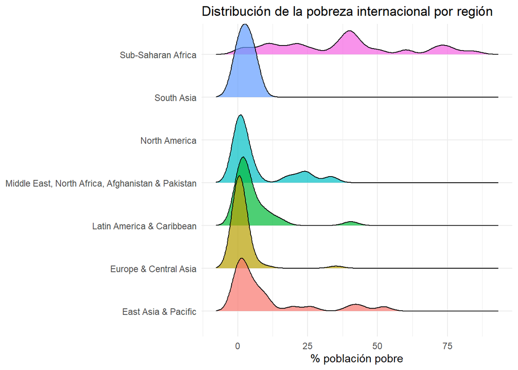

```r
pobint %>%
  drop_na(region) %>%
  ggplot(aes(x = umbral_pobreza_internacional, y = region, fill = region)) +
  geom_density_ridges(alpha = 0.7) +
  theme_minimal() +
  theme(legend.position = "none") +
  labs(title = "Distribución de la pobreza internacional por región",
       x = "% población pobre", y = NULL)
```

### Países con menos porcentaje de población pobre, por región.

```r
pobna_reg2 = pobnac %>%
  left_join(codelist %>% rename(GeoAreaCode=iso3n)) %>%
  group_by(region) %>%
  slice_min(umbral_pobreza_nacional) %>%
  select(region,iso3c,country, umbral_pobreza_nacional, date) %>%
  arrange(umbral_pobreza_nacional)
tab_pvna_reg2 <- pobna_reg2 %>%
  ungroup()  %>%
  mutate(date=as.integer(date)) %>%
  flextable::flextable() %>%
  flextable::colformat_double(digits = 2) %>%
flextable::set_caption("Países con menor porcentaje de población pobre (variable nacional) por región")
```

```r
pobint_reg2 <- pobint %>%
  left_join(codelist %>% rename(GeoAreaCode = iso3n)) %>%
  group_by(region) %>%
  arrange(
    umbral_pobreza_internacional,
    desc(date),
    .by_group = TRUE
  ) %>%
  slice(1) %>%
  select(region, iso3c, country,
         umbral_pobreza_internacional, date)
tab_pvint_reg2 <- pobint_reg2 %>%
  ungroup()  %>%
  mutate(date=as.integer(date)) %>%
  flextable::flextable() %>%
  flextable::colformat_double(digits = 2) %>%
flextable::set_caption("Países con menor porcentaje de población pobre (variable internacional) por región")
```

```r
pobmix_reg2 = pobmix %>%
  left_join(codelist %>% rename(GeoAreaCode=iso3n)) %>%
  group_by(region) %>%
  slice_min(difference) %>%
  select(region,iso3c,country,difference, date) %>%
  arrange(difference)
tab_pvmix_reg2 <- pobmix_reg2 %>%
  ungroup()  %>%
  mutate(date=as.integer(date)) %>%
  flextable::flextable() %>%
  flextable::colformat_double(digits = 2) %>%
flextable::set_caption("Países con menor diferencia entre variable nacional e internacional por región")
```

Países con menor porcentaje de población pobre (variable nacional) por región

| region | iso3c | country | Poverty headcount ratio at national poverty lines (% of population) | date |
| --- | --- | --- | --- | --- |
| East Asia & Pacific | CHN | China | 0.00 | 2,020 |
| Europe & Central Asia | BLR | Belarus | 3.50 | 2,024 |
| Middle East, North Africa, Afghanistan & Pakistan | MAR | Morocco | 3.90 | 2,022 |
| South Asia | MDV | Maldives | 5.40 | 2,019 |
| Latin America & Caribbean | CHL | Chile | 6.50 | 2,022 |
| Sub-Saharan Africa | MUS | Mauritius | 8.40 | 2,023 |

Países con menor porcentaje de población pobre (variable internacional) por región

| region | iso3c | country | Poverty headcount ratio at $3.00 a day (2021 PPP) (% of population) | date |
| --- | --- | --- | --- | --- |
| East Asia & Pacific | THA | Thailand | 0.00 | 2,024 |
| Europe & Central Asia | CYP | Cyprus | 0.00 | 2,023 |
| Latin America & Caribbean | LCA | St. Lucia | 0.10 | 2,015 |
| Middle East, North Africa, Afghanistan & Pakistan | ARE | United Arab Emirates | 0.00 | 2,018 |
| North America | CAN | Canada | 0.30 | 2,022 |
| South Asia | BTN | Bhutan | 0.00 | 2,022 |
| Sub-Saharan Africa | MUS | Mauritius | 0.50 | 2,017 |

Países con menor diferencia entre variable nacional e internacional por región

| region | iso3c | country | difference | date |
| --- | --- | --- | --- | --- |
| Sub-Saharan Africa | UGA | Uganda | -39.50 | 2,019 |
| East Asia & Pacific | SLB | Solomon Islands | -27.60 | 2,012 |
| South Asia | IND | India | -5.20 | 2,011 |
| Middle East, North Africa, Afghanistan & Pakistan | DJI | Djibouti | -4.30 | 2,017 |
| Europe & Central Asia | UZB | Uzbekistan | 3.50 | 2,025 |
| Latin America & Caribbean | CHL | Chile | 5.90 | 2,022 |

### Países con mayor porcentaje de población pobre

```r
pobna20L = pobnac %>%
     group_by(region) %>%
     ungroup() %>%
     arrange(-umbral_pobreza_nacional) %>%
     select(region,country,umbral_pobreza_nacional,date) %>%
     slice(1:20)

tab_pvna_H <- pobna20L %>%
  ungroup()  %>%
  mutate(date=as.integer(date)) %>%
  flextable::flextable() %>%
  flextable::colformat_double(digits = 2) %>%
  flextable::set_caption("Países con más % de población por debajo del umbral nacional de pobreza")
```

```r
pobint20L = pobint %>%
     group_by(region) %>%
     ungroup() %>%
     arrange(-umbral_pobreza_internacional) %>%
     select(region,country,umbral_pobreza_internacional,date) %>%
     slice(1:20)

tab_pvint_H <- pobint20L %>%
  ungroup()  %>%
  mutate(date=as.integer(date)) %>%
  flextable::flextable() %>%
  flextable::colformat_double(digits = 2) %>%
  flextable::set_caption("Países con más % de población por debajo del umbral internacional de pobreza")
```

En las dos tablas siguientes vemos los países con el mayor porcentaje de pobreza en las dos variables donde, aunque hay alguna diferencia en los nombres y en las dos tablas no se ven los mismos países, es claro que África subsahariana predomina en ambas tablas.

Países con más % de población por debajo del umbral nacional de pobreza

| region | country | Poverty headcount ratio at national poverty lines (% of population) | date |
| --- | --- | --- | --- |
| Sub-Saharan Africa | South Sudan | 82.30 | 2,016 |
| Sub-Saharan Africa | Madagascar | 75.20 | 2,021 |
| Sub-Saharan Africa | Central African Republic | 68.80 | 2,021 |
| Sub-Saharan Africa | Mozambique | 65.00 | 2,022 |
| Latin America & Caribbean | Honduras | 60.10 | 2,025 |
| Sub-Saharan Africa | Zambia | 60.00 | 2,022 |
| Sub-Saharan Africa | Eswatini | 58.90 | 2,016 |
| Latin America & Caribbean | Haiti | 58.50 | 2,012 |
| Sub-Saharan Africa | Sierra Leone | 56.80 | 2,018 |
| Sub-Saharan Africa | Congo, Dem. Rep. | 56.20 | 2,020 |
| Sub-Saharan Africa | Nigeria | 56.20 | 2,022 |
| Latin America & Caribbean | Guatemala | 56.00 | 2,023 |
| Sub-Saharan Africa | Sao Tome and Principe | 55.50 | 2,017 |
| Sub-Saharan Africa | Somalia, Fed. Rep. | 55.40 | 2,022 |
| Sub-Saharan Africa | Gambia, The | 53.40 | 2,020 |
| Latin America & Caribbean | Belize | 52.00 | 2,018 |
| Sub-Saharan Africa | Burundi | 51.00 | 2,020 |
| Sub-Saharan Africa | Liberia | 50.90 | 2,016 |
| Sub-Saharan Africa | Equatorial Guinea | 50.70 | 2,022 |
| Sub-Saharan Africa | Malawi | 50.70 | 2,019 |

Países con más % de población por debajo del umbral internacional de pobreza

| region | country | Poverty headcount ratio at $3.00 a day (2021 PPP) (% of population) | date |
| --- | --- | --- | --- |
| Sub-Saharan Africa | Congo, Dem. Rep. | 85.30 | 2,020 |
| Sub-Saharan Africa | Mozambique | 81.40 | 2,022 |
| Sub-Saharan Africa | South Sudan | 76.50 | 2,016 |
| Sub-Saharan Africa | Malawi | 75.40 | 2,019 |
| Sub-Saharan Africa | Burundi | 74.20 | 2,020 |
| Sub-Saharan Africa | Zambia | 71.70 | 2,022 |
| Sub-Saharan Africa | Central African Republic | 71.60 | 2,021 |
| Sub-Saharan Africa | Madagascar | 69.20 | 2,021 |
| Sub-Saharan Africa | Niger | 60.50 | 2,021 |
| Sub-Saharan Africa | Uganda | 59.80 | 2,019 |
| East Asia & Pacific | Papua New Guinea | 52.20 | 2,009 |
| Sub-Saharan Africa | Tanzania | 51.30 | 2,018 |
| Sub-Saharan Africa | Zimbabwe | 49.20 | 2,019 |
| Sub-Saharan Africa | Kenya | 45.50 | 2,022 |
| Sub-Saharan Africa | Eswatini | 44.50 | 2,016 |
| East Asia & Pacific | Timor-Leste | 44.00 | 2,014 |
| Sub-Saharan Africa | Burkina Faso | 42.10 | 2,021 |
| Sub-Saharan Africa | Lesotho | 41.90 | 2,017 |
| Sub-Saharan Africa | Nigeria | 41.80 | 2,022 |
| Sub-Saharan Africa | Sierra Leone | 41.50 | 2,018 |

Un gráfico interactivo para mostrar los 20 países con más pobres según la variable nacional:

```r
p <- pobna20L %>%
  ggplot(aes(x = reorder(country, umbral_pobreza_nacional),
             y = umbral_pobreza_nacional,
             fill = region,
             text = paste("País:", country,
                          "<br>Pobreza:", round(umbral_pobreza_nacional, 1), "%",
                          "<br>Región:", region))) +
  geom_col() +
  coord_flip() +
  theme_minimal() +
  labs(title = "Top 20 países con mayor pobreza nacional",
       x = NULL, y = "% población pobre")

ggplotly(p, tooltip = "text")
```

[interactive chart not shown]

### Países con menor porcentaje de población pobre.

```r
#
pobna20W = pobnac %>%
     group_by(region) %>%
     ungroup() %>%
     arrange(umbral_pobreza_nacional) %>%
     select(region,country,umbral_pobreza_nacional,date) %>%
     slice(1:15)

tab_pvna_L <- pobna20W %>%
  ungroup()  %>%
  mutate(date=as.integer(date)) %>%
  flextable::flextable() %>%
  flextable::colformat_double(digits = 2) %>%
  flextable::set_caption("Países con menos % de población por debajo del umbral nacional de pobreza")
```

```r
pobint20W = pobint %>%
     group_by(region) %>%
     ungroup() %>%
     arrange(umbral_pobreza_internacional) %>%
     select(region,country,umbral_pobreza_internacional,date) %>%
     slice(1:15)

tab_pvint_L <- pobint20W %>%
  ungroup()  %>%
  mutate(date=as.integer(date)) %>%
  flextable::flextable() %>%
  flextable::colformat_double(digits = 2) %>%
  flextable::set_caption("Países con menos % de población por debajo del umbral internacional de pobreza")
```

[output not shown]

[output not shown]

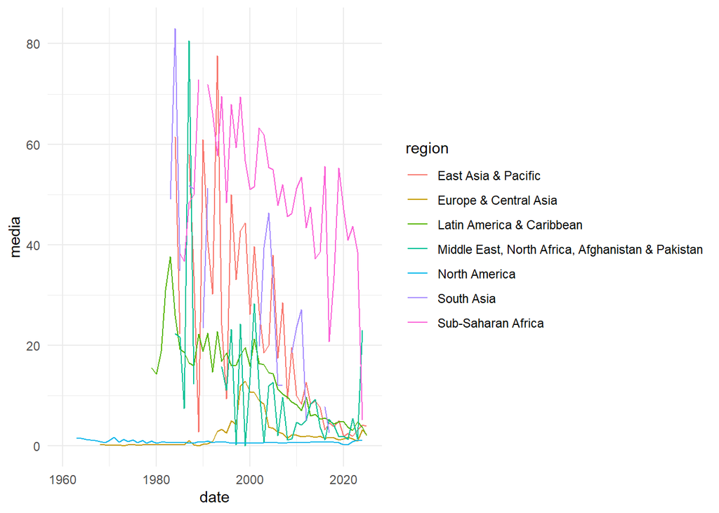

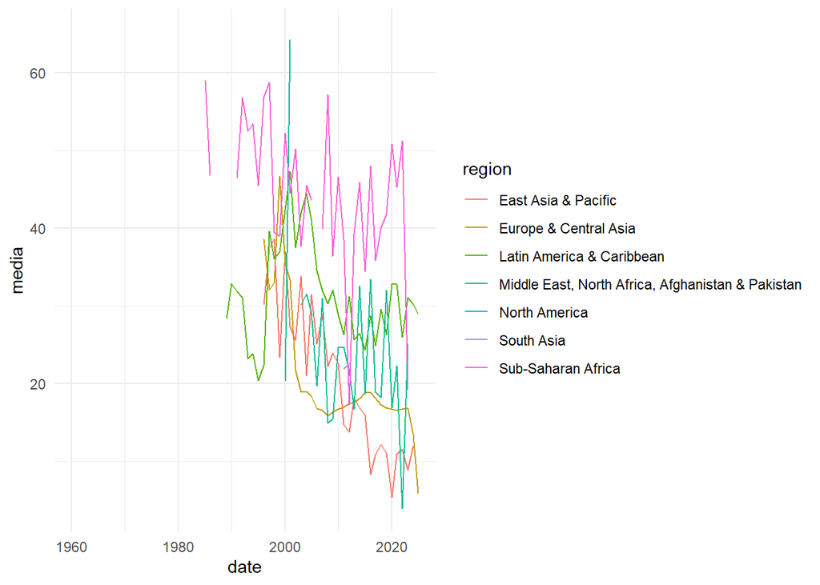

```r
his1 <- data_set %>%
  group_by(region, date) %>%
  summarize(media = mean(umbral_pobreza_internacional, na.rm = TRUE)) %>%
  ggplot(aes(x = date, y = media, color = region)) +
  geom_line() +
  theme_minimal()
his2 <- data_set %>%
  group_by(region, date) %>%
  summarize(media = mean(umbral_pobreza_nacional, na.rm = TRUE)) %>%
  ggplot(aes(x = date, y = media, color = region)) +
  geom_line() +
  theme_minimal()
```

## Gráficos de mapa mundial.

Para poder mapear nuestros datos, tenemos que trasladarlos al `Mundo`. Veamos cómo:

```r
library(tmap)
data(World)
```

```r
map = World %>%
  filter(iso_a3 != "ATA") %>%
  left_join(pobnac %>% rename(iso_a3=iso3c) %>%      select(iso_a3,umbral_pobreza_nacional),
     by="iso_a3")
```

Se mostrarán los datos obtenidos a través del World Bank en forma de mapa, con una leyenda en colores que nos mostrará cuánto porcentaje de población vive por debajo del umbral de la pobreza, medido según el indicador correspondiente, en cada país. También se ha creado un mapa que muestre los países que más diferencias presentan entre las pobrezas viviendo en pobreza según el indicador nacional el internacional.

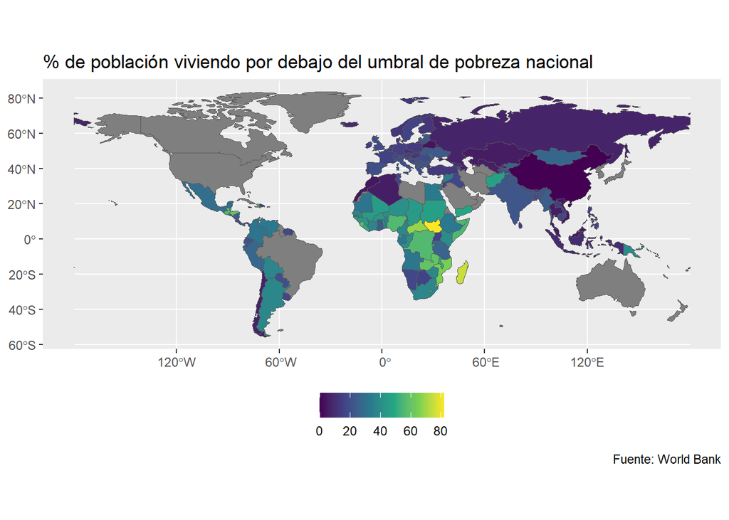

```r
map %>% ggplot(aes(fill = umbral_pobreza_nacional)) +
  geom_sf() +
  scale_fill_viridis_c() +
  theme(legend.position="bottom") +
  labs(
    title = "% de población viviendo por debajo del umbral de pobreza nacional",
    fill = NULL,
    caption = paste("Fuente: World Bank")
  ) +
   coord_sf()
```

```r
map = World %>%
  filter(iso_a3 != "ATA") %>%
  left_join(pobint %>% rename(iso_a3=iso3c) %>%      select(iso_a3,country,umbral_pobreza_internacional),
     by="iso_a3")
```

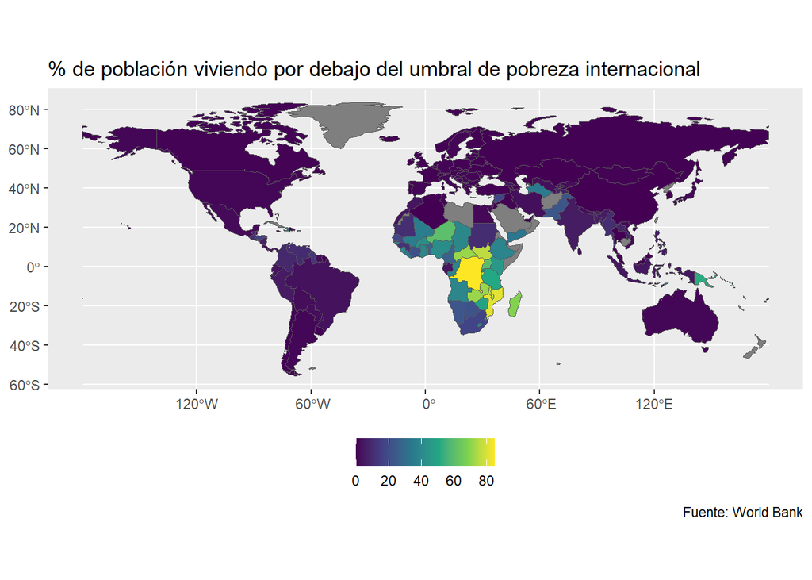

```r
map %>% ggplot(aes(fill = umbral_pobreza_internacional)) +
  geom_sf() +
  scale_fill_viridis_c() +
  theme(legend.position="bottom") +
  labs(
    title = "% de población viviendo por debajo del umbral de pobreza internacional",
    fill = NULL,
    caption = paste("Fuente: World Bank")
  ) +
   coord_sf()
```

```r
map = World %>%
  filter(iso_a3 != "ATA") %>%
  left_join(pobmix %>% rename(iso_a3=iso3c) %>% select(iso_a3,country,difference),
     by="iso_a3")
```

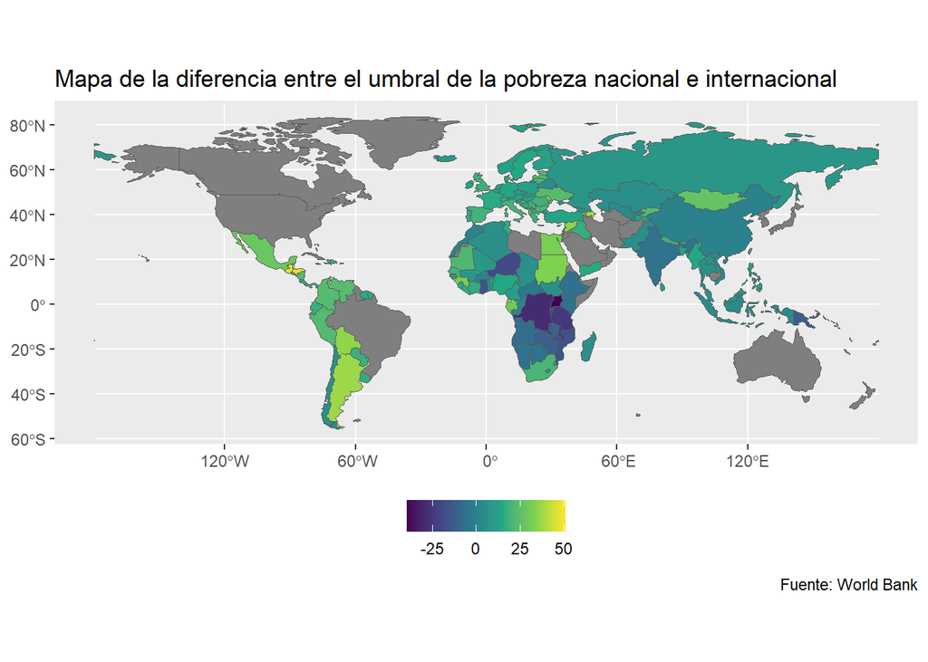

```r
map %>% ggplot(aes(fill = difference)) +
  geom_sf() +
  scale_fill_viridis_c() +
  theme(legend.position="bottom") +
  labs(
    title = "Mapa de la diferencia entre el umbral de la pobreza nacional e internacional",
    fill = NULL,
    caption = paste("Fuente: World Bank")
  ) +
   coord_sf()
```

### Añadimos la variable PIB

```r
tab_PIB_H <- pobint %>%
  group_by(region) %>%
  arrange(umbral_pobreza_internacional) %>%
  slice(1) %>%
  select(region,country,PIB_capita) %>%  flextable::flextable() %>%
  flextable::colformat_double(digits = 0) %>%
   flextable::set_caption("Países con más % de población por debajo del umbral nacional de pobreza según PIB")
```

```r
tab_PIB_L <- pobint %>%
  group_by(region) %>%
  arrange(-umbral_pobreza_internacional) %>%
  slice(1) %>%
  select(region,country,PIB_capita) %>%  flextable::flextable() %>%
  flextable::colformat_double(digits = 0) %>%
  flextable::set_caption("Países con menos % de población por debajo del umbral nacional de pobreza según PIB")
```

| region | country | GDP per capita (current US$) |
| --- | --- | --- |
| East Asia & Pacific | China | 12,971 |
| Europe & Central Asia | Azerbaijan | 1,578 |
| Latin America & Caribbean | St. Lucia | 10,335 |
| Middle East, North Africa, Afghanistan & Pakistan | Algeria | 5,916 |
| North America | Canada | 56,257 |
| South Asia | Bhutan | 3,711 |
| Sub-Saharan Africa | Mauritius | 10,987 |

| region | country | GDP per capita (current US$) |
| --- | --- | --- |
| East Asia & Pacific | Papua New Guinea | 1,569 |
| Europe & Central Asia | Turkmenistan | 591 |
| Latin America & Caribbean | Haiti | 1,361 |
| Middle East, North Africa, Afghanistan & Pakistan | Yemen, Rep. | 1,430 |
| North America | United States | 84,534 |
| South Asia | Bangladesh | 2,716 |
| Sub-Saharan Africa | Congo, Dem. Rep. | 486 |

```r
tab_nac_wght <- pobnac %>%
  group_by(region) %>%
  drop_na(poblacion) %>%
  summarize(`Promedio ponderado`=weighted.mean(umbral_pobreza_nacional,poblacion,na.rm=TRUE),
 `Promedio simplificado`=mean(umbral_pobreza_nacional,na.rm=TRUE),
 Countries=n(),
 Missing=sum(is.na(umbral_pobreza_nacional)),
 `Población (en millones)`=sum(poblacion)/1e6
            ) %>%
  arrange(`Promedio ponderado`) %>% flextable::flextable() %>%
  flextable::colformat_double(digits = 2) %>%
  flextable::set_caption("Promedio, ponderado y simplificado, del % de pobreza (V. Nacional) por región")
```

```r
tab_int_wght <- pobint %>%
  group_by(region) %>%
  drop_na(poblacion) %>%
  summarize(`Promedio ponderado`=weighted.mean(umbral_pobreza_internacional,poblacion,na.rm=TRUE),
 `Promedio simplificado`=mean(umbral_pobreza_internacional,na.rm=TRUE),
 Countries=n(),
 Missing=sum(is.na(umbral_pobreza_internacional)),
 `Población (en millones)`=sum(poblacion)/1e6
            ) %>%
  arrange(`Promedio ponderado`) %>% flextable::flextable() %>%
  flextable::colformat_double(digits = 2) %>%
   flextable::set_caption("Promedio, ponderado y simplificado, del % de pobreza (V. Internacional) por región")
```

Promedio, ponderado y simplificado, del % de pobreza (V. Nacional) por región

| region | Promedio ponderado | Promedio simplificado | Countries | Missing | Población (en millones) |
| --- | --- | --- | --- | --- | --- |
| East Asia & Pacific | 3.55 | 18.45 | 22 | 0 | 2,105.06 |
| Europe & Central Asia | 14.70 | 16.16 | 47 | 0 | 882.70 |
| South Asia | 21.38 | 15.50 | 6 | 0 | 1,483.40 |
| Middle East, North Africa, Afghanistan & Pakistan | 24.98 | 24.54 | 14 | 0 | 579.40 |
| Latin America & Caribbean | 31.45 | 29.18 | 20 | 0 | 386.13 |
| Sub-Saharan Africa | 44.51 | 42.99 | 46 | 0 | 1,172.34 |

Promedio, ponderado y simplificado, del % de pobreza (V. Internacional) por región

| region | Promedio ponderado | Promedio simplificado | Countries | Missing | Población (en millones) |
| --- | --- | --- | --- | --- | --- |
| Europe & Central Asia | 0.65 | 1.65 | 48 | 0 | 889.09 |
| East Asia & Pacific | 1.00 | 10.45 | 23 | 0 | 2,010.45 |
| North America | 1.02 | 0.70 | 2 | 0 | 379.05 |
| Latin America & Caribbean | 4.35 | 5.52 | 25 | 0 | 619.16 |
| South Asia | 5.27 | 2.72 | 6 | 0 | 1,647.60 |
| Middle East, North Africa, Afghanistan & Pakistan | 11.57 | 6.90 | 17 | 0 | 674.60 |
| Sub-Saharan Africa | 45.59 | 37.32 | 46 | 0 | 1,154.00 |

El gráfico que se muestra aquí representa la comparación entre las dos variables, donde se aprecian claramente las grandes diferencias que hemos encontrado a lo largo de este trabajo. Vemos, por ejemplo, que Asia Oriental y el Pacífico es la región con menor población pobre y, al mismo tiempo, con menor diferencia entre las variables. Algo similar ocurre con la región de África Subsahariana, donde encontramos mayor consenso entre las dos variables, y ambas coinciden en que es la región más afectada por este problema.

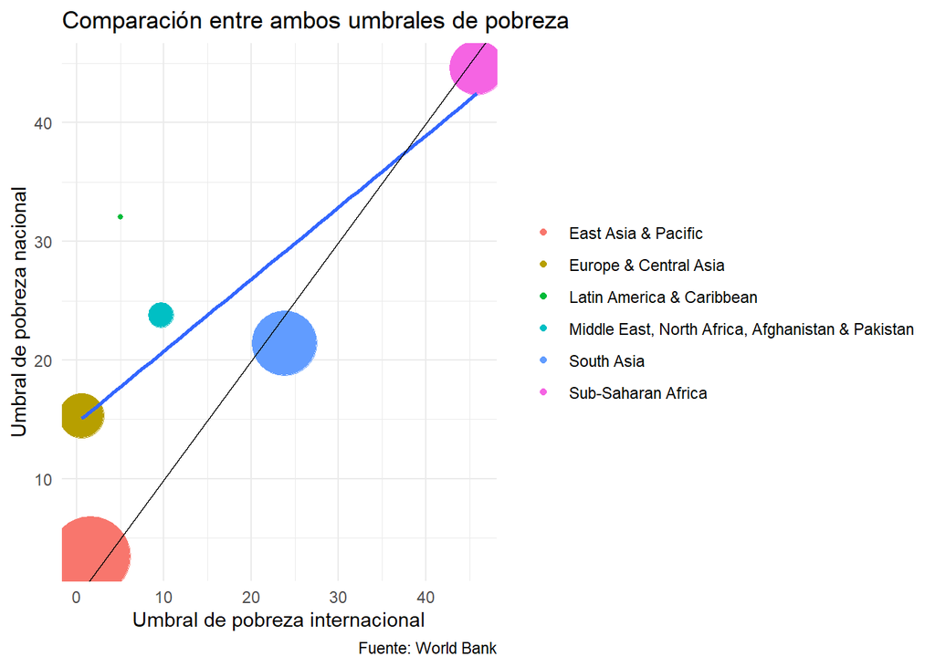

```r
pobmix %>%
  group_by(region) %>%
  drop_na(poblacion) %>%
  summarize(Nacional=weighted.mean(umbral_pobreza_nacional,poblacion,na.rm=TRUE),
 Internacional=weighted.mean(umbral_pobreza_internacional,poblacion,na.rm=TRUE),
 Countries=n(),
 `Población (en millones)`=sum(poblacion)/1e6) %>%
  ggplot(aes(
      x = Internacional,
      y = Nacional
      )) +
  geom_point(aes(size=`Población (en millones)`, color=region)) +
  geom_smooth(se = FALSE,method="lm") +
  geom_abline(slope=1,intercept=0) +
  scale_size_continuous(
    labels = scales::number_format(scale = 1/1e6, suffix = "m"),
    breaks = seq(1e8,1e9, 2e8),
    range = c(1,20)
    ) +
  theme_minimal() +
  labs(
    title = "Comparación entre ambos umbrales de pobreza",
    x = "Umbral de pobreza internacional",
    y = "Umbral de pobreza nacional",
    size = "Población",
    color = NULL,
    caption = "Fuente: World Bank"
  )
```

### % de población pobre según PIB per cápita.

```r
graf1 <- pobmix %>%
  ggplot(aes(
      x = PIB_capita,
      y = umbral_pobreza_nacional
      )) +
  geom_point(aes(size=poblacion, color=region)) +
  geom_smooth(se = FALSE) +
  scale_x_log10(
    labels = scales::dollar_format(),
    breaks = scales::log_breaks(n = 4)
  ) +
  scale_size_continuous(
    labels = scales::number_format(scale = 1/1e6, suffix = "m"),
    breaks = seq(1e8,1e9, 2e8),
    range = c(1,20)
    ) +
  theme_minimal() +
  labs(
    title = "Umbral de pobreza nacional según PIB per cápita del país",
    x = "PIB per cápita",
    y = "Umbral de pobreza nacional",
    size = "Población",
    color = NULL,
    caption = "Fuente: World Bank"
  )
```

```r
graf2 <- pobmix %>%
  ggplot(aes(
      x = PIB_capita,
      y = umbral_pobreza_internacional
      )) +
  geom_point(aes(size=poblacion, color=region)) +
  geom_smooth(se = FALSE) +
  scale_x_log10(
    labels = scales::dollar_format(),
    breaks = scales::log_breaks(n = 4)
  ) +
  scale_size_continuous(
    labels = scales::number_format(scale = 1/1e6, suffix = "m"),
    breaks = seq(1e8,1e9, 2e8),
    range = c(1,20)
    ) +
  theme_minimal() +
  labs(
    title = "Umbral de pobreza internacional según el PIB per cápita del país",
    x = "PIB per cápita",
    y = "Umbral de pobreza internacional",
    size = "Población",
    color = NULL,
    caption = "Fuente: World Bank"
  )
```

Los siguientes gráficos nos muestran la relación entre el PIB per cápita y el porcentaje de población pobre de un país.

[interactive chart not shown]

[interactive chart not shown]

Los siguientes chunks de código son una preparación para visualizar los datos del resto de nuestras variables comparándolos con los datos de población por debajo del umbral internacional de pobreza, para ver si existe relación.

```r
por_desnutricion = data_set %>%
     group_by(country) %>%
     drop_na(umbral_pobreza_internacional) %>%
     drop_na(desnutrición) %>%
     arrange(-date) %>%
     slice(1)
```

```r
acabar_secundaria = data_set %>%
     group_by(country) %>%
     drop_na(umbral_pobreza_internacional) %>%
     drop_na(tasa_secundaria_inferior) %>%
     arrange(-date) %>%
     slice(1)
```

```r
barrios_marginales = data_set %>%
     group_by(country) %>%
     drop_na(umbral_pobreza_internacional) %>%
     drop_na(poblacion_barrios_marginales) %>%
     arrange(-date) %>%
     slice(1)
```

```r
graf3 <- por_desnutricion %>%
  ggplot(aes(
      x = umbral_pobreza_internacional,
      y = desnutrición
      )) +
  geom_point(aes(size=poblacion, color=region)) +
  geom_smooth(se = FALSE) +
  scale_size_continuous(
    labels = scales::number_format(scale = 1/1e6, suffix = "m"),
    breaks = seq(1e8,1e9, 2e8),
    range = c(1,20)
    ) +
  theme_minimal() +
  labs(
    title = "Desnutrición según % de población viviendo por debajo del umbral internacional de pobreza",
    x = "Umbral de pobreza internacional",
    y = "Desnutrición (% de la población)",
    size = "Población",
    color = NULL,
    caption = "Fuente: World Bank"
  )
```

```r
graf4 <- acabar_secundaria %>%
  ggplot(aes(
      x = umbral_pobreza_internacional ,
      y = tasa_secundaria_inferior
      )) +
  geom_point(aes(size=poblacion, color=region)) +
  geom_smooth(se = FALSE) +
  scale_size_continuous(
    labels = scales::number_format(scale = 1/1e6, suffix = "m"),
    breaks = seq(1e8,1e9, 2e8),
    range = c(1,20)
    ) +
  theme_minimal() +
  labs(
    title = "% de población que acaba 1er ciclo de secundaria según umbral de pobreza internacional ",
    x = "Umbral de pobreza internacional",
    y = "Tasa de finalización del ciclo inferior de la educación secundaria",
    size = "Población",
    color = NULL,
    caption = "Fuente: World Bank"
  )
```

```r
graf5 <- barrios_marginales %>%
  ggplot(aes(
      x = umbral_pobreza_internacional,
      y = poblacion_barrios_marginales
      )) +
  geom_point(aes(size=poblacion, color=region)) +
  geom_smooth(se = FALSE) +
  scale_size_continuous(
    labels = scales::number_format(scale = 1/1e6, suffix = "m"),
    breaks = seq(1e8,1e9, 2e8),
    range = c(1,20)
    ) +
  theme_minimal() +
  labs(
    title = "Personas viviendo en barrios marginales según umbral pobreza internacional",
    x = "Umbral de pobreza internacional",
    y = "% Población que vive en barrios marginales",
    size = "Población",
    color = NULL,
    caption = "Fuente: World Bank"
  )
```

Veremos ahora gráficamente cómo se relacionan estos datos:

[interactive chart not shown]

[interactive chart not shown]

[interactive chart not shown]

Haremos lo mismo ahora, pero para comparar estos datos con el porcentaje de población en cada país que vive por debajo del umbral nacional de pobreza

```r
por_desnutricion2 = data_set %>%
     group_by(country) %>%
     drop_na(umbral_pobreza_nacional) %>%
     drop_na(desnutrición) %>%
     arrange(-date) %>%
     slice(1)
```

```r
acabar_secundaria2 = data_set %>%
     group_by(country) %>%
     drop_na(umbral_pobreza_nacional) %>%
     drop_na(tasa_secundaria_inferior) %>%
     arrange(-date) %>%
     slice(1)
```

```r
barrios_marginales2 = data_set %>%
     group_by(country) %>%
     drop_na(umbral_pobreza_nacional) %>%
     drop_na(poblacion_barrios_marginales) %>%
     arrange(-date) %>%
     slice(1)
```

```r
graf6 <- por_desnutricion2 %>%
  ggplot(aes(
      x = umbral_pobreza_nacional,
      y = desnutrición
      )) +
  geom_point(aes(size=poblacion, color=region)) +
  geom_smooth(se = FALSE) +
  scale_size_continuous(
    labels = scales::number_format(scale = 1/1e6, suffix = "m"),
    breaks = seq(1e8,1e9, 2e8),
    range = c(1,20)
    ) +
  theme_minimal() +
  labs(
    title = "Desnutrición según % de población viviendo por debajo del umbral nacional de pobreza",
    x = "Umbral nacional de pobreza",
    y = "Desnutrición (% de la población)",
    size = "Población",
    color = NULL,
    caption = "Fuente: World Bank"
  )
```

```r
graf7 <- acabar_secundaria2 %>%
  ggplot(aes(
      x = umbral_pobreza_nacional,
      y = tasa_secundaria_inferior
      )) +
  geom_point(aes(size=poblacion, color=region)) +
  geom_smooth(se = FALSE) +
  scale_size_continuous(
    labels = scales::number_format(scale = 1/1e6, suffix = "m"),
    breaks = seq(1e8,1e9, 2e8),
    range = c(1,20)
    ) +
  theme_minimal() +
  labs(
    title = "% de población que acaba 1er ciclo de secundaria según umbral de pobreza nacional ",
    x = "Umbral de pobreza internacional",
    x = "Umbral nacional de pobreza",
    y = "Tasa de finalización del ciclo inferior de la educación secundaria",
    size = "Población",
    color = NULL,
    caption = "Fuente: World Bank"
  )
```

```r
graf8 <- barrios_marginales2 %>%
  ggplot(aes(
      x = umbral_pobreza_nacional,
      y = poblacion_barrios_marginales
      )) +
  geom_point(aes(size=poblacion, color=region)) +
  geom_smooth(se = FALSE) +
  scale_size_continuous(
    labels = scales::number_format(scale = 1/1e6, suffix = "m"),
    breaks = seq(1e8,1e9, 2e8),
    range = c(1,20)
    ) +
  theme_minimal() +
  labs(
    title = "Personas viviendo en barrios marginales según umbral pobreza nacional",
    x = "Umbral nacional de pobreza",
    y = "% Población que vive en barrios marginales",
    size = "Población",
    color = NULL,
    caption = "Fuente: World Bank"
  )
```

Y aquí vemos los gráficos:

[interactive chart not shown]

[interactive chart not shown]

[interactive chart not shown]

## Mapa interactivo

Por último, para cerrar el presente trabajo, hemos diseñado un mapa interactivo que te permite ver en el mapa los porcentajes de población pobre según los umbrales nacionales e internacionales, así como la diferencia entre estos; y un gráfico dinámico que muestra la evolución temporal de la pobreza de los países y de su PIB per cápita.

```r
tmap_mode("view")
```

```
## ℹ tmap modes "plot" - "view"
## ℹ toggle with `tmap::ttm()`
```

```r
data("World")

data_mapa <- World %>%
  left_join(
    pobmix %>% ungroup() %>% select(iso3c, umbral_pobreza_nacional,
                                     umbral_pobreza_internacional, difference),
    by = c("iso_a3" = "iso3c")
  )

tmap_mode("view")
```

```
## ℹ tmap modes "plot" - "view"
```

```r
tm_shape(data_mapa) +
  tm_polygons(
    col = "umbral_pobreza_internacional",
    palette = "YlOrRd",
    title = "% pobreza internacional",
    popup.vars = c("País" = "name",
                   "Pobreza internacional" = "umbral_pobreza_internacional",
                   "Pobreza nacional" = "umbral_pobreza_nacional",
                   "Diferencia" = "difference")
  )
```

[output not shown]

[interactive chart not shown]

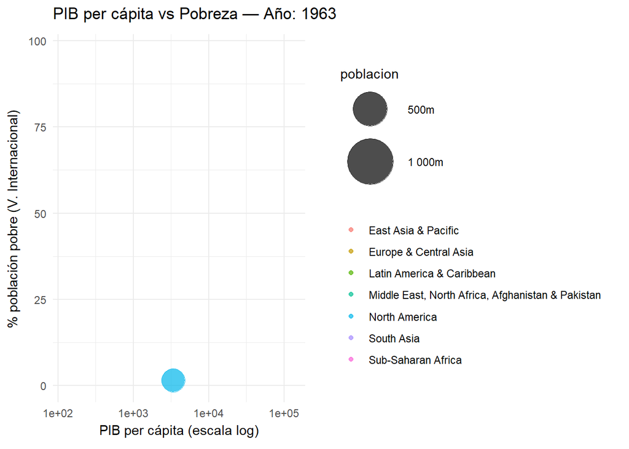

```r
data_set %>%
  drop_na(PIB_capita, umbral_pobreza_internacional, poblacion) %>%
  drop_na(region) %>%
  ggplot(aes(x = PIB_capita, y = umbral_pobreza_internacional,
             size = poblacion, color = region)) +
  geom_point(alpha = 0.7) +
  scale_x_log10() +
  scale_size_continuous(range = c(2, 20),
                        labels = scales::number_format(scale = 1/1e6, suffix = "m")) +
  theme_minimal() +
  labs(title = "PIB per cápita vs Pobreza — Año: {frame_time}",
       x = "PIB per cápita (escala log)",
       y = "% población pobre (V. Internacional)",
       color = NULL) +
  transition_time(date) +
  ease_aes("linear")
```